# 20191001

# Chapter 10 Data visualization in preactice

: faceting, time series plots, transformations, ridge plots

## 10.1 Case study: new insights on poverty

In this section, we use data to attempt to answer the following two questions:

1. Is it a fair characterization of today’s world to say it is divided into western rich nations and the developing world in Africa, Asia and Latin America?
2. Has income inequality across countries worsened during the last 40 years?

We will be using the `gapminder` dataset provided in dslabs.

```r
library(tidyverse)
library(dslabs)
data(gapminder)
gapminder %>% as_tibble()
```

| country | year | infant_mortality | life_expectancy | fertility | population | gdp | continent | region |
| --- | --- | --- | --- | --- | --- | --- | --- | --- |
| Albania | 1960 | 115.40 | 62.87 | 6.19 | 1636054 | NA | Europe | Southern Europe |
| Algeria | 1960 | 148.20 | 47.50 | 7.65 | 11124892 | 1.382815e+10 | Africa | Northern Africa |
| Angola | 1960 | 208.00 | 35.98 | 7.32 | 5270844 | NA | Africa | Middle Africa |
| Antigua and Barbuda | 1960 | NA | 62.97 | 4.43 | 54681 | NA | Americas | Caribbean |
| Argentina | 1960 | 59.87 | 65.39 | 3.11 | 20619075 | 1.083223e+11 | Americas | South America |
| Armenia | 1960 | NA | 66.86 | 4.55 | 1867396 | NA | Asia | Western Asia |
| Aruba | 1960 | NA | 65.66 | 4.82 | 54208 | NA | Americas | Caribbean |
| Australia | 1960 | 20.30 | 70.87 | 3.45 | 10292328 | 9.667786e+10 | Oceania | Australia and New Zealand |
| Austria | 1960 | 37.30 | 68.75 | 2.70 | 7065525 | 5.239270e+10 | Europe | Western Europe |
| Azerbaijan | 1960 | NA | 61.33 | 5.57 | 3897889 | NA | Asia | Western Asia |

[output cut: 990 more lines]

### 10.1.1 Hans Rosling’s quiz

- differences in child mortality across different countries

Q. which country do you think had the highest child mortality rates in 2015? 1) Sri Lanka or Turkey 2) Poland or South Korea 3) Malaysia or Russia 4) Pakistan or Vietnam 5) Thailand or South Africa

To answer these questions with data, we can use dplyr.

```r
gapminder %>%
  filter(year == 2015 & country %in% c("Sri Lanka","Turkey")) %>%
  select(country, infant_mortality)
```

| country | infant_mortality |
| --- | --- |
| Sri Lanka | 8.4 |
| Turkey | 11.6 |

Turkey has the higher infant mortality rate.

## 10.2 Scatterplots

- the western world (Western Europe and North America): long life spans and small families
- the developing world (Africa, Asia, and Latin America): short life spans and large families.

We can check this view using `gapminder` table.

scatterplot of life expectancy versus fertility rates: (average number of children per woman).

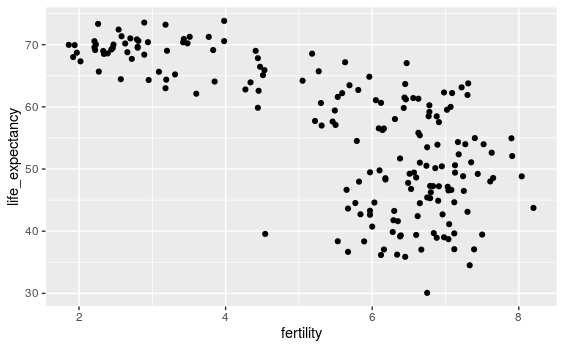

```r
filter(gapminder, year == 1962) %>%
  ggplot(aes(fertility, life_expectancy)) +
  geom_point()
```

Most points fall into two distinct categories:

1. Life expectancy around 70 years and 3 or less children per family.
2. Life expectancy lower then 65 years and more than 5 children per family.

To confirm that indeed these countries are from the regions we expect, we can use color to represent continent.

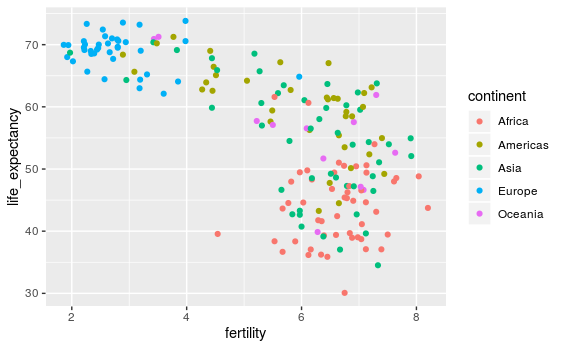

```r
filter(gapminder, year == 1962) %>%
  ggplot( aes(fertility, life_expectancy, color = continent)) +
  geom_point()
```

Is this still the case 50 years later?

## 10.3 Faceting

To make comparisons between 2962 and 2012, side by side plots are preferable. -> faceting variables (stratify the data by some variable and make the same plot for each strata)

**To achieve faceting, we add a layer with the function `facet_grid`**

separates the plot

facet by up to two variables using columns to represent one variable and rows to represent the other

the row and column variables to be separated by a`~`

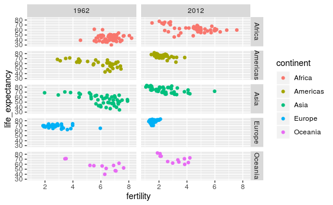

```r
filter(gapminder, year%in%c(1962, 2012)) %>%
  ggplot(aes(fertility, life_expectancy, col = continent)) +
  geom_point() +
  facet_grid(continent~year)
```

We simply want to compare 1962 and 2012 -> use `.` for just one variable = let facet know that we are not using one of the variables:

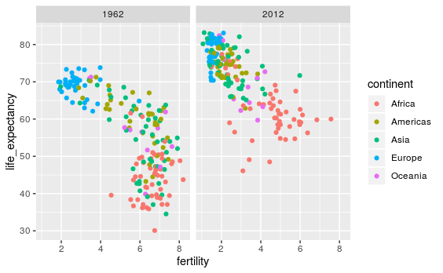

```r
filter(gapminder, year%in%c(1962, 2012)) %>%
  ggplot(aes(fertility, life_expectancy, col = continent)) +
  geom_point() +
  facet_grid(. ~ year)
```

In 2012, the western versus developing world view no longer makes sense.

### 10.3.1 `facet_wrap`

we will not want all the plots on the same row -> `facet_grid` we will want to use multiple rows and columns -> `facet_wrap`

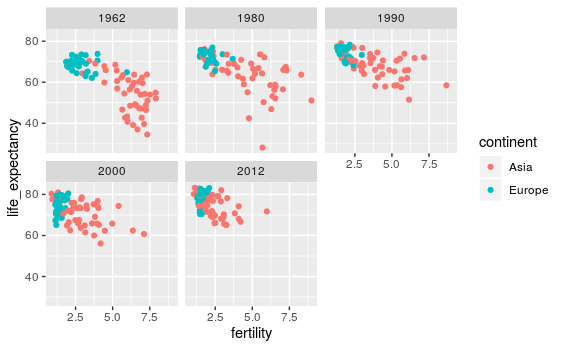

```r
years <- c(1962, 1980, 1990, 2000, 2012)
continents <- c("Europe", "Asia")
gapminder %>%
  filter(year %in% years & continent %in% continents) %>%
  ggplot( aes(fertility, life_expectancy, col = continent)) +
  geom_point() +
  facet_wrap(~year)
```

### 10.3.2 10.3.2 Fixed scales for better comparisons

Range of the axes is important.

not using `facet`: range = determined by data shown in the plot. using `facet`: range = determined by the data shown in all plot

## 10.4 Time series plots

Q. which countries are improving more and which ones less? Was the improvement constant during the last 50 years or was it more accelerated during certain periods?

-> time series plots

x-axia: time, y-axis: outcome or measurement of interest

trend plot of United States fertility rates:

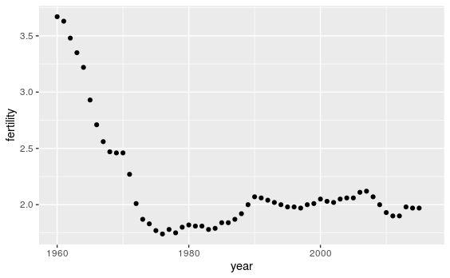

```r
gapminder %>%
  filter(country == "United States") %>%
  ggplot(aes(year, fertility)) +
  geom_point()
```

We see that the trend is not linear at all.

we create curves by joining the points with lines = to convey that these data are from a single series (country)

To do this, we use the `geom_line` function instead of `geom_point.`

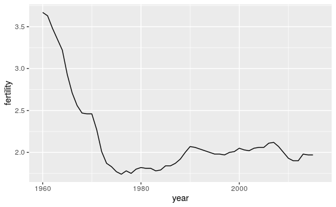

```r
gapminder %>%
  filter(country == "United States") %>%
  ggplot(aes(year, fertility)) +
  geom_line()
```

This is particularly helpful when we look at two countries.

If we subset the data to include two countries, one from Europe and one from Asia, then adapt the code above:

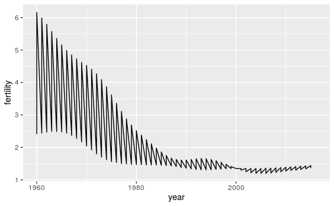

```r
countries <- c("South Korea","Germany")

gapminder %>% filter(country %in% countries) %>%
  ggplot(aes(year,fertility)) +
  geom_line()
```

this is not the plot that we want. Rather than a line for each country, the points for both countries are joined.

two curves that need to be made separately, we assign each point to a `group`, one for each country:

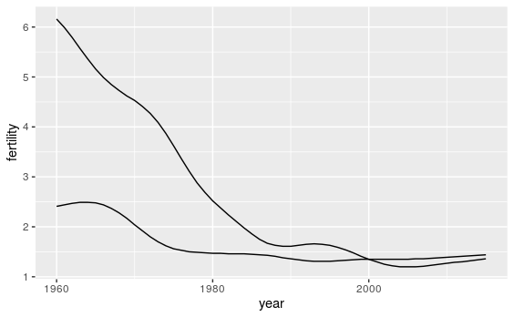

```r
countries <- c("South Korea","Germany")

gapminder %>% filter(country %in% countries & !is.na(fertility)) %>%
  ggplot(aes(year, fertility, group = country)) +
  geom_line()
```

But which line goes with which country? We can assign colors to make this distinction

using the `color` argument to assign different colors to the different countries is that the data is automatically grouped:

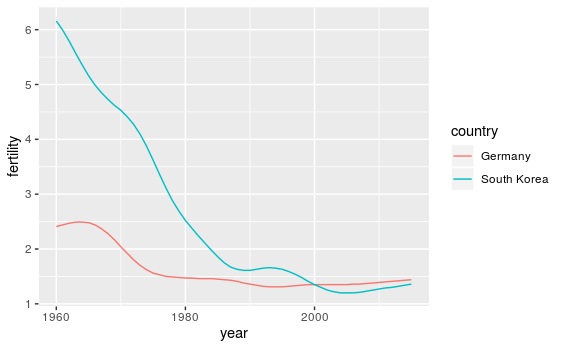

```r
countries <- c("South Korea","Germany")

gapminder %>% filter(country %in% countries & !is.na(fertility)) %>%
  ggplot(aes(year,fertility, col = country)) +
  geom_line()
```

### 10.4.1 Labels instead of legends

labeling the lines rather than using legends

We define a data table with the label locations and then use a second mapping just for these labels:

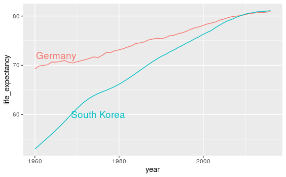

```r
labels <- data.frame(country = countries, x = c(1975,1965), y = c(60,72))

gapminder %>%
  filter(country %in% countries) %>%
  ggplot(aes(year, life_expectancy, col = country)) +
  geom_line() +
  geom_text(data = labels, aes(x, y, label = country), size = 5) +
  theme(legend.position = "none")
```

## 10.5 Data transformations

Q.wealth distribution across the world has become worse during the last decades?

The gapminder data table includes a column with the countries gross domestic product (GDP). The GDP per person is often used as a rough summary of a country’s wealth. -> divide GDP per person by 365 to obtain the more interpretable measure *dollars per day.*

- income of less than $2 a day: living in absolute poverty.

```r
gapminder <- gapminder %>%  mutate(dollars_per_day = gdp/population/365)
```

### 10.5.1 Log transformation

histogram of per day incomes from 1970:

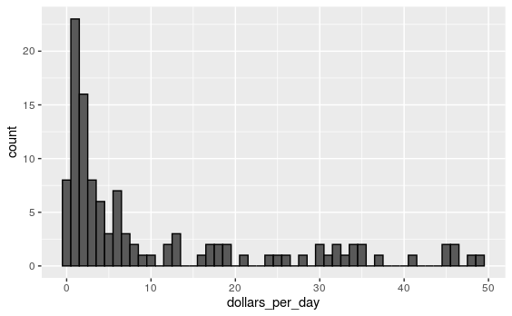

```r
past_year <- 1970
gapminder %>%
  filter(year == past_year & !is.na(gdp)) %>%
  ggplot(aes(dollars_per_day)) +
  geom_histogram(binwidth = 1, color = "black")
```

We use the color = “black” argument to draw a boundary and clearly distinguish the bins.

how many countries have average daily incomes of about $1 (extremely poor), $2 (very poor), $4 (poor), $8 (middle), $16 (well off), $32 (rich), $64 (very rich) per day.

**-> multiplicative and log transformations convert multiplicative changes into additive ones**

when using base 2, a doubling of a value turns into an increase by 1.

the distribution if we apply a log base 2 transform:

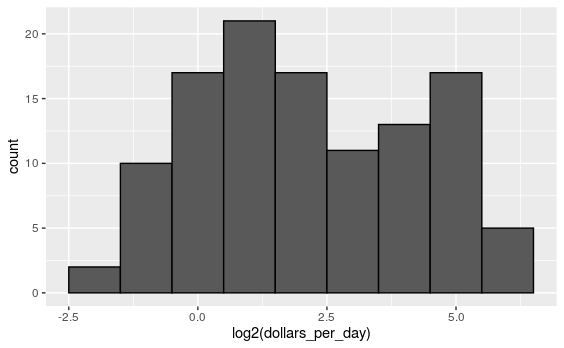

```r
gapminder %>%
  filter(year == past_year & !is.na(gdp)) %>%
  ggplot(aes(log2(dollars_per_day))) +
  geom_histogram(binwidth = 1, color = "black")
```

### 10.5.2 Which base?

In the case above, we used base 2 in the log transformations. Other common choices are 1) base e-the natural log- and 2) base 10.

In the dollars per day example, we used base 2, because the resulting range is easier to interpret. The range of the values being plotted is 0.327, 48.885.

In base 10, this turns into a range that includes very few integers: just 0 and 1

With log base 2, we know that a binwidth of 1 will translate to a bin with range x to 2x.

For an example in which base 10 makes more sense, consider population sizes. A log base 10 is preferable since the range for these is:

```r
filter(gapminder, year == past_year) %>%
  summarize(min = min(population), max = max(population))
```

| min | max |
| --- | --- |
| 46075 | 808510713 |

histogram of the transformed values:

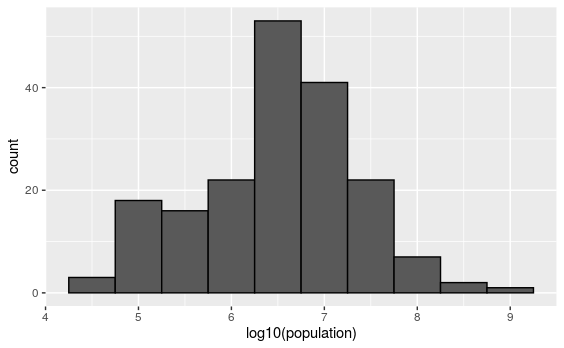

```r
gapminder %>%
  filter(year == past_year) %>%
  ggplot(aes(log10(population))) +
  geom_histogram(binwidth = 0.5, color = "black")
```

### 10.5.3 Transform the values or the scale?

We can log the values before plotting them or use log scales in the axes.

if we want to scale the axis with logs, we can use the `scale_x_continuous` function, we apply this layer: (log scales in the axes)

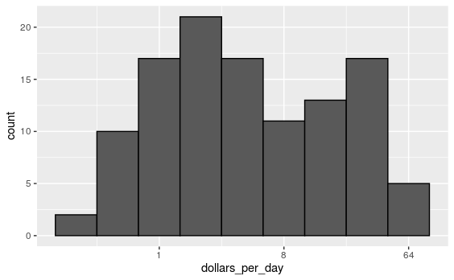

```r
gapminder %>%
  filter(year == past_year & !is.na(gdp)) %>%
  ggplot(aes(dollars_per_day)) +
  geom_histogram(binwidth = 1, color = "black") +
  scale_x_continuous(trans = "log2")
```

the log base 10 transformation has its own function: `scale_x_log10()`

There are other transformations available through the `trans` argument. The logistic transformation (`logit`): plotting proportions between 0 and 1. The `reverse` transformation: when we want smaller values to be on the right or on top.

## 10.6 Visualizing multimodal distributions

The mode of a distribution is the value with the highest frequency. The mode of the normal distribution is the average.

When a distributiondoesn’t monotonically decrease from the mode :`local modes` = *multiple modes*

## 10.7 Comparing multiple distributions with boxplots and ridge plots

Histogram showed us that 1970 income distribution but does not show us if the two groups of countries are *west* versus the *developing world*.

Let’s start by quickly examining the data by region.

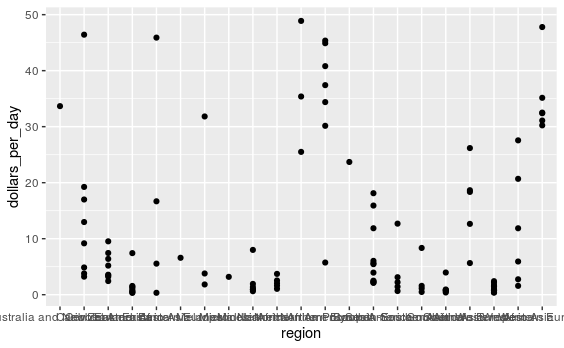

```r
p <- gapminder %>%
  filter(year == past_year & !is.na(gdp)) %>%
  ggplot(aes(region, dollars_per_day))
p + geom_point()
```

we can’t read the region names -> rotating the axes or rotating the labels.

we can rotate the axes: `coord_flip` we can rotate the labels: changing the theme through `element_text.`

The `hjust = 1`: the text so that it is next to the axis.

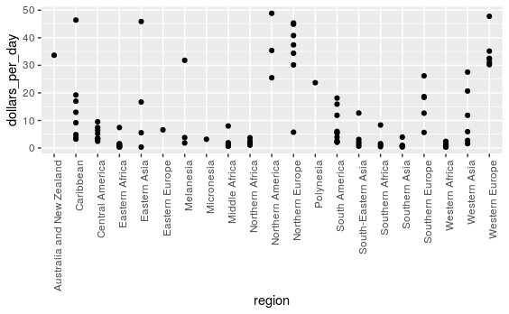

```r
p + geom_point() +
  theme(axis.text.x = element_text(angle = 90, hjust = 1))
```

do not order alphabetically!

using the reorder function:

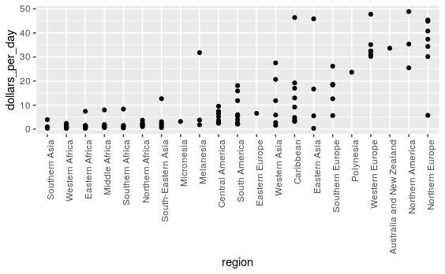

```r
p <- gapminder %>%
  filter(year == past_year & !is.na(gdp)) %>%
  mutate(region = reorder(region, dollars_per_day, FUN = median)) %>%
  ggplot(aes(region, dollars_per_day)) +
  geom_point() +
  theme(axis.text.x = element_text(angle = 90, hjust = 1))
p
```

if we remake the plot using a log scale. This permits us to better appreciate the differences within the developing world:

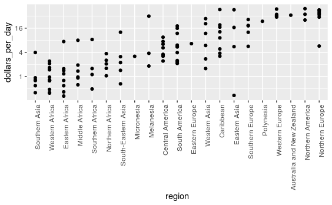

```r
p + scale_y_continuous(trans = "log2")
```

### 10.7.1 Boxplots

rich countries: Europe and North America, along with Australia and New Zealand.

This fact and the variability observed in the rest of the countries motivates us to define the following give groups:

```r
gapminder <- gapminder %>%
  mutate(group = case_when(
    region %in% c("Western Europe", "Northern Europe","Southern Europe",
                    "Northern America", "Australia and New Zealand") ~ "West",
    region %in% c("Eastern Asia", "South-Eastern Asia") ~ "East Asia",
    region %in% c("Caribbean", "Central America", "South America") ~ "Latin America",
    continent == "Africa" & region != "Northern Africa" ~ "Sub-Saharan Africa",
    TRUE ~ "Others"))
```

We turn this group variable into a factor to control the order of the levels:

```r
gapminder <- gapminder %>%
  mutate(group = factor(group,
                        levels = c("Others", "Latin America", "East Asia", "Sub-Saharan Africa", "West")))
```

We now want to compare the distribution across these five groups to confirm the “west versus the rest” dichotomy.

We could generate five histograms or five density plots, but it may be more practical to have all the visual summaries in one plot.

We therefore start by stacking boxplots next to each other.

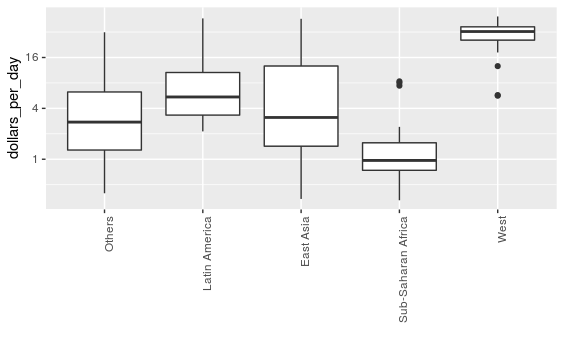

```r
p <- gapminder %>%
  filter(year == past_year & !is.na(gdp)) %>%
  ggplot(aes(group, dollars_per_day)) +
  geom_boxplot() +
  theme(axis.text.x = element_text(angle = 90, hjust = 1)) +
  scale_y_continuous(trans = "log2") +
  xlab("")
p
```

Boxplots have the limitation that by summarizing the data into five numbers, we might miss important characteristics of the data. One way to avoid this is by showing the data.

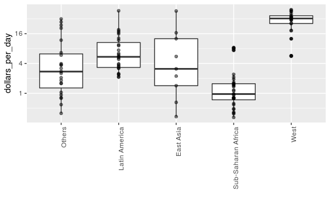

```r
p + geom_point(alpha = 0.5)
```

### 10.7.2 Ridge plots

when the number of data points is so large that there is over-plotting, showing the data can be counterproductive.

Boxplots help with this by providing a five-number summary, but this has limitations too. = bimodal distribution

boxplot summary is too simplistic -> ridge plots

Here is the income data shown above with boxplots but with a ridge plot.

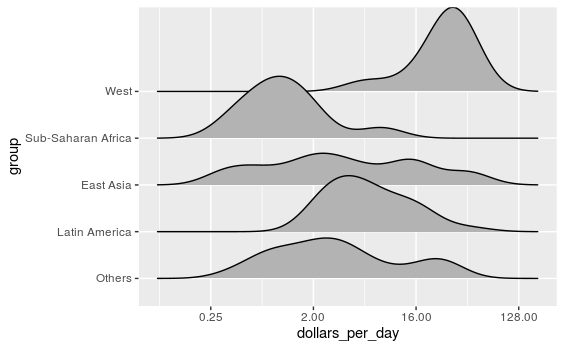

```r
library(ggridges)
p <- gapminder %>%
  filter(year == past_year & !is.na(dollars_per_day)) %>%
  ggplot(aes(dollars_per_day, group)) +
  scale_x_continuous(trans = "log2")
p  + geom_density_ridges()
```

we have to invert the `x` and `y` used for the boxplot.

A useful `geom_density_ridges` parameter is `scale`, which lets you determine the amount of overlap, with `scale = 1` meaning no overlap and larger values resulting in more overlap.

If the number of data points is small enough, we can add them to the ridge plot using the following code:

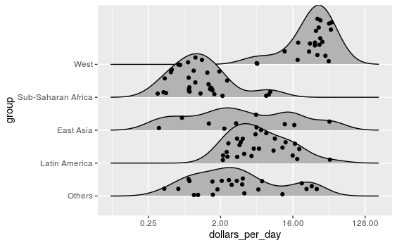

```r
p + geom_density_ridges(jittered_points = TRUE)
```

the height of the points is jittered and should not be interpreted in any way.

To show data points, but without using jitter = use rug representation

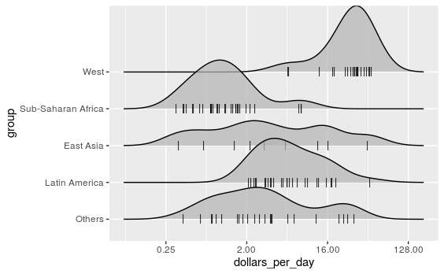

```r
p + geom_density_ridges(jittered_points = TRUE,
                        position = position_points_jitter(width = 0.05, height = 0),
                        point_shape = '|', point_size = 3, point_alpha = 1, alpha = 0.7)
```

### 10.7.3 Example: 1970 versus 2010 income distributions

Let’s use `facet_grid` see how the distributions have changed.

To start, we will focus on two groups: the west and the rest.

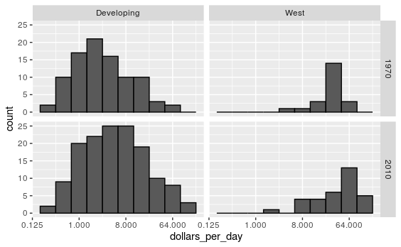

```r
past_year <- 1970
present_year <- 2010
gapminder %>%
  filter(year %in% c(past_year, present_year) & !is.na(gdp)) %>%
  mutate(west = ifelse(group == "West", "West", "Developing")) %>%
  ggplot(aes(dollars_per_day)) +
  geom_histogram(binwidth = 1, color = "black") +
  scale_x_continuous(trans = "log2") +
  facet_grid(year ~ west)
```

here are more countries represented in the 2010 histograms than in 1970: the total counts are larger.

We remake the plots using only countries with data available for both years. -> we can use simple code using the `intersect` function:

```r
country_list_1 <- gapminder %>%
  filter(year == past_year & !is.na(dollars_per_day)) %>%
  pull(country)

country_list_2 <- gapminder %>%
  filter(year == present_year & !is.na(dollars_per_day)) %>%
  pull(country)

country_list <- intersect(country_list_1, country_list_2)
```

Let’s remake the plot, but only for this subset by simply adding `country %in% country_list` to the `filter` function:

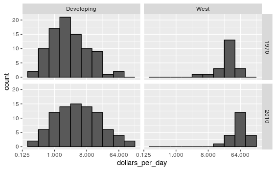

```r
past_year <- 1970
present_year <- 2010
gapminder %>%
  filter(year %in% c(past_year, present_year) & country %in% country_list & !is.na(gdp)) %>%
  mutate(west = ifelse(group == "West", "West", "Developing")) %>%
  ggplot(aes(dollars_per_day)) +
  geom_histogram(binwidth = 1, color = "black") +
  scale_x_continuous(trans = "log2") +
  facet_grid(year ~ west)
```

In particular, we see that the proportion of developing countries earning more than $16 a day increased substantially.

To see which specific regions improved the most, we can remake the boxplots we made above, but now adding the year 2010 and then using facet to compare the two years.

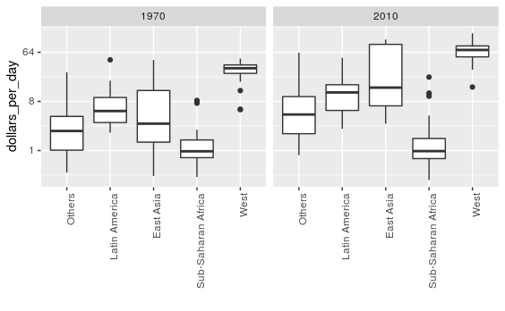

```r
gapminder %>%
  filter(year %in% c(past_year, present_year) & country %in% country_list) %>%
  ggplot(aes(group, dollars_per_day)) +
  geom_boxplot() +
  theme(axis.text.x = element_text(angle = 90, hjust = 1)) +
  scale_y_continuous(trans = "log2") +
  xlab("") +
  facet_grid(. ~ year)
```

we want to compare each region before and after, comparison are easier when data of 1970 and 2010 are plotted next to each other.

So instead of faceting, we keep the data from each year together and ask to color (or fill) them depending on the year.

Because year is a number, we turn it into a factor. (we have to convert the year columns from numeric to factor.)

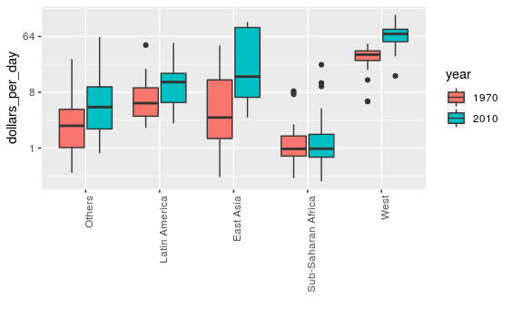

```r
gapminder %>%
  filter(year %in% c(past_year, present_year) & country %in% country_list) %>%
  mutate(year = factor(year)) %>%
  ggplot(aes(group, dollars_per_day, fill = year)) +
  geom_boxplot() +
  theme(axis.text.x = element_text(angle = 90, hjust = 1)) +
  scale_y_continuous(trans = "log2") +
  xlab("")
```

Let’s start by noting that density plots for income distribution in 1970 and 2010 deliver the message that the gap is closing:

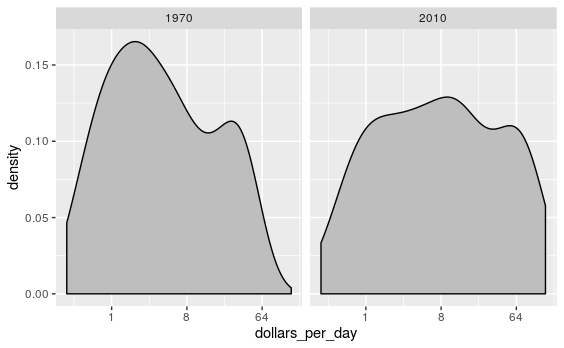

```r
gapminder %>%
  filter(year %in% c(past_year, present_year) & country %in% country_list) %>%
  ggplot(aes(dollars_per_day)) +
  geom_density(fill = "grey") +
  scale_x_continuous(trans = "log2") +
  facet_grid(. ~ year)
```

In the 1970 plot, we see two clear modes: poor and rich countries. In 2010, it appears that some of the poor countries have shifted towards the right, closing the gap.

Newt, we want to show the reason for this change in distribution is that several poor countries became richer, rather than some rich countries becoming poorer.

To do this, we can assign a color to the groups we identified during data exploration.

-> we first need to learn how to make these smooth densities in a way that preserves information on the number of countries in each group. (the discrepancy in the size of each group)

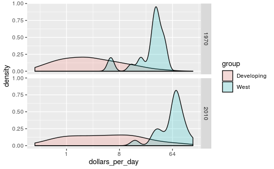

```r
gapminder %>%
  filter(year %in% c(past_year, present_year) & country %in% country_list) %>%
  mutate(group = ifelse(group == "West", "West", "Developing")) %>%
  ggplot(aes(dollars_per_day, fill = group)) +
  scale_x_continuous(trans = "log2") +
  geom_density(alpha = 0.2) +
  facet_grid(year ~ .)
```

there are the same number of countries in each group. To change this, we will need to learn to access computed variables with `geom_density` function.

### 10.7.4 Accessing computed variables

To have the areas of these densities be proportional to the size of the groups, we can simply multiply the y-axis values by the size of the group. -> `count` do this, in ggplot2: `..`

We will also expand the limits of the x-axis.

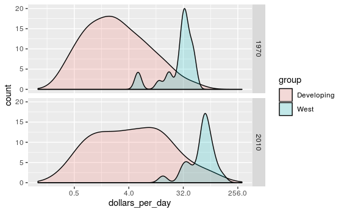

```r
p <- gapminder %>%
  filter(year %in% c(past_year, present_year) & country %in% country_list) %>%
  mutate(group = ifelse(group == "West", "West", "Developing")) %>%
  ggplot(aes(dollars_per_day, y = ..count.., fill = group)) +
  scale_x_continuous(trans = "log2", limit = c(0.125, 300))

p + geom_density(alpha = 0.2) +
  facet_grid(year ~ .)
```

To be smoother, we use the `bw` argument -> the same bandwidth is used in each density. (0.75)

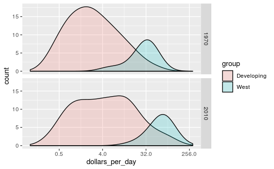

```r
p + geom_density(alpha = 0.2, bw = 0.75) + facet_grid(year ~ .)
```

This plot now shows what is happening very clearly. The developing world distribution is changing. A third mode appears consisting of the countries that most narrowed the gap.

To visualize if any of the groups defined above are driving this we can quickly make a ridge plot:

```
Ignoring unknown parameters: adjust
```

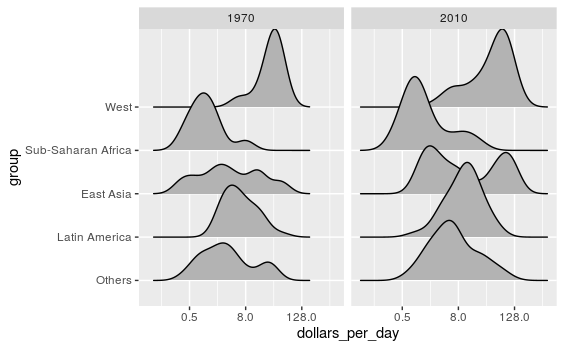

```r
gapminder %>%
  filter(year %in% c(past_year, present_year) & !is.na(dollars_per_day)) %>%
  ggplot(aes(dollars_per_day, group)) +
  scale_x_continuous(trans = "log2") +
  geom_density_ridges(adjust = 1.5) +
  facet_grid(. ~ year)
```

Another way to achieve this is by stacking the densities on top of each other:

[figure not shown]

```r
gapminder %>%
    filter(year %in% c(past_year, present_year) & country %in% country_list) %>%
  group_by(year) %>%
  mutate(weight = population/sum(population)*2) %>%
  ungroup() %>%
  ggplot(aes(dollars_per_day, fill = group)) +
  scale_x_continuous(trans = "log2", limit = c(0.125, 300)) +
  geom_density(alpha = 0.2, bw = 0.75, position = "stack") + facet_grid(year ~ .)
```

Here we can clearly see how the distributions for East Asia, Latin America and others shift markedly to the right.

### 10.7.5 Weighted densities

We can actually weight the smooth densities using the `weight` mapping argument.

The plot then looks like this:

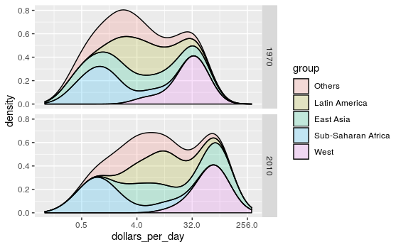

```r
gapminder %>%
    filter(year %in% c(past_year, present_year) & country %in% country_list) %>%
  group_by(year) %>%
  mutate(weight = population/sum(population)*2) %>%
  ungroup() %>%
  ggplot(aes(dollars_per_day, fill = group)) +
  scale_x_continuous(trans = "log2", limit = c(0.125, 300)) +
  geom_density(alpha = 0.2, bw = 0.75, position = "stack", weight = "weight") + facet_grid(year ~ .)
```

This particular figure shows very clearly how the income distribution gap is closing with most of the poor remaining in Sub-Saharan Africa.

## 10.8 The ecological fallacy and importance of showing the data

We focus on describing the importance of variability within the groups when examining the relationship between a country’s infant mortality rates and average income.

We start by comparing these quantities across regions, but before doing this, we define a few more regions:

```r
gapminder <- gapminder %>%
  mutate(group = case_when(
    region %in% c("Western Europe", "Northern Europe","Southern Europe",
                    "Northern America", "Australia and New Zealand") ~ "West",
    region %in% "Northern Africa" ~ "Northern Africa",
    region %in% c("Eastern Asia", "South-Eastern Asia") ~ "East Asia",
    region == "Southern Asia"~ "Southern Asia",
    region %in% c("Central America", "South America", "Caribbean") ~ "Latin America",
    continent == "Africa" & region != "Northern Africa" ~ "Sub-Saharan Africa",
    region %in% c("Melanesia", "Micronesia", "Polynesia") ~ "Pacific Islands"))
```

We then compute these quantities for each region:

```r
surv_income <- gapminder %>%
  filter(year %in% present_year & !is.na(gdp) &
           !is.na(infant_mortality) & !is.na(group)) %>%
  group_by(group) %>%
  summarize(income = sum(gdp)/sum(population)/365,
            infant_survival_rate =
              1 - sum(infant_mortality/1000*population)/sum(population))

surv_income %>% arrange(income)
```

| group | income | infant_survival_rate |
| --- | --- | --- |
| Sub-Saharan Africa | 1.759299 | 0.9358607 |
| Southern Asia | 2.070296 | 0.9521295 |
| Pacific Islands | 2.704745 | 0.9560088 |
| Northern Africa | 4.942935 | 0.9703514 |
| Latin America | 13.244228 | 0.9831732 |
| East Asia | 13.439078 | 0.9848303 |
| West | 77.065524 | 0.9951445 |

This shows a dramatic difference. While in the West less than 0.5% of infants die, in Sub-Saharan Africa the rate is higher than 6%!

The relationship between these two variables is almost perfectly linear:

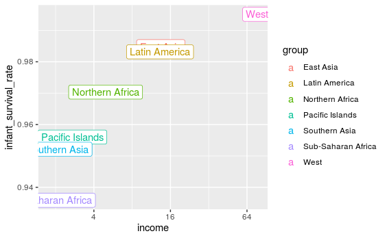

```r
surv_income <- gapminder %>%
  filter(year %in% present_year & !is.na(gdp) &
           !is.na(infant_mortality) & !is.na(group)) %>%
  group_by(group) %>%
  summarize(income = sum(gdp)/sum(population)/365,
            infant_survival_rate =
              1 - sum(infant_mortality/1000*population)/sum(population))

surv_income %>%
  ggplot(aes(income, infant_survival_rate, label = group, color = group)) +
  scale_x_continuous(trans = "log2") +
  geom_label()
```

### 10.8.1 Logistic transformation

In this case p is the proportion of infants that survived.

When p is a proportion or probability -> odds

This scale is useful when we want to highlight differences near 0 or 1.